# Above- and belowground linkages shape responses of mountain vegetation to climate change | Science

#### share

Review

# Above- and belowground linkages shape responses of mountain vegetation to climate change

1. [View ORCID Profile](https://orcid.org/0000-0001-5218-7776)Frank Hagedorn<sup>1</sup>,*,
2. [View ORCID Profile](https://orcid.org/0000-0003-4479-7202)Konstantin Gavazov<sup>1</sup>,†,
3. [View ORCID Profile](https://orcid.org/0000-0003-2226-7913)Jake M. Alexander<sup>2</sup>,†

Science 13 Sep 2019:  
Vol. 365, Issue 6458, pp. 1119-1123  
DOI: 10.1126/science.aax4737

## Abstract

Upward shifts of mountain vegetation lag behind rates of climate warming, partly related to interconnected changes belowground. Here, we unravel above- and belowground linkages by drawing insights from short-term experimental manipulations and elevation gradient studies. Soils will likely gain carbon in early successional ecosystems, while losing carbon as forest expands upward, and the slow, high-elevation soil development will constrain warming-induced vegetation shifts. Current approaches fail to predict the pace of these changes and how much they will be modified by interactions among plants and soil biota. Integrating mountain soils and their biota into monitoring programs, combined with innovative comparative and experimental approaches, will be crucial to overcome the paucity of belowground data and to better understand mountain ecosystem dynamics and their feedbacks to climate.

The distinct zonation of mountain vegetation has inspired generations of biologists interested in how environmental—especially climatic—variation shapes ecosystem structure and function (*1*, *2*), and mountain plants have served as bioindicators for the impacts of climate changes over the last century (*3*). Despite comprising only 12% of the terrestrial surface, mountains host high levels of biodiversity and provide crucial ecosystem services [e.g., carbon (C) storage, raw material provisioning, natural hazard protection, water reservoirs] with far-reaching effects on lowland ecosystems and global climate (*4*). Mountain ecosystems are experiencing especially strong climate warming (*5*). The expected warming of 2° to 4°C this century (*5*) could extend vegetation zones and the thermal limits of plant life upward by as much as 300 to 600 m in elevation, with profound consequences for ecosystem functioning (Fig. 1). However, although responses of mountain vegetation have been widely studied aboveground, there are parallel changes occurring in the “dark” side of ecosystems belowground, where plant roots and their associated microbial communities form a complex but largely unknown world in the soil. Alpine soils above the treeline store more than 90% of ecosystem C (*4*), and thus even small changes in soil C storage will have a large effect on the overall climate balance of mountain ecosystems (*6*). Soils also provide nutrients to sustain plant growth, which is strongly nutrient limited in mountain plants (*7*, *8*), so changes in nutrient availability and in soil microbial community composition could represent a strong modifier of vegetation shifts in a warming climate (*9*). In this review, we show how plant communities, soils, and their associated microorganisms are interlinked in mountain ecosystems; identify how belowground ecosystems might respond to vegetation shifts in a changing climate; and, finally, indicate how short- and long-term changes in C and nutrient cycling may feed back to climate and modify vegetation shifts.

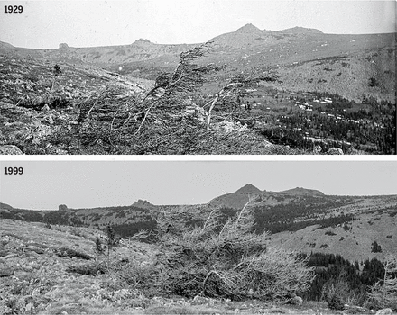

Fig. 1 Mountain landscapes in transition.

Comparisons of present and historic photographs give evidence for the upward migration of trees to higher elevations in remote areas of the Ural Mountains in response to the climatic warming in the 20th century [from (*37*)]. The forest expansion is paralleled by changes in the belowground ecosystem.

## Elevation shifts of mountain vegetation

Mountains have characteristic vegetation belts transitioning from forest, heathland, and alpine grassland up to the nival zone with a permanent snow cover (Fig. 2). Although vegetation forms a mosaic controlled by parent materials, soil development, and topography at the local scale, climate conditions are of primary importance for the formation of distinct vegetation belts along mountain slopes, such as at treeline (*10*–*12*) and at the upper limit of vascular plant life (*13*). Temperatures belowground are more buffered than those aboveground and remain lower for the duration of the short vegetative season, critically limiting plant growth below ~5°C (*4*, *14*). Because of their climate sensitivity, shifts in the distributions of individual plant species and vegetation types to higher elevations therefore provide evidence for the impact of climate warming on natural ecosystems worldwide (*3*, *15*). Revisiting Humboldt’s plant surveys documents an upward migration of ~250 m over 215 years (*2*). During this century, the colonization of new species has accelerated on European mountains (*3*), and even the upper limit of continuous plant life has advanced at high elevations, such as in the northwest Himalaya (*13*), in marked synchrony with increased rates of climate warming (*3*). Treelines are expanding at 52% of 166 sites around the world (Fig. 1) (*12*), and available evidence also suggests that shrublines are advancing upward in the Northern Hemisphere, consistent with increasing shrub encroachment in tundra vegetation at high latitudes (*16*).

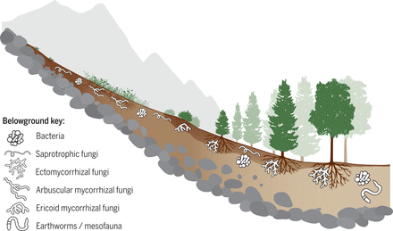

Fig. 2 Mountain ecosystems above and below the ground.

Vegetation forms distinct belts across climatic gradients in elevation, spanning the nival zone with cryptogams and cushion plants, alpine grassland and heathlands, and subalpine forests (*1*, *2*, *4*). These vegetation zones are paralleled belowground. The contribution of roots to total plant biomass typically increases with elevation (*51*), as perennial plants relocate resources belowground to survive harsh alpine winters. Early successional ecosystems store very little soil organic matter (SOM) owing to low plant inputs and slow weathering (*49*) and host highly specific microbial taxa (*50*, *52*, *60*). Alpine grasslands have typically high SOM contents in the topsoil as low temperatures impede the decomposition of annual inputs of fine roots and leaf litter (*45*). The herbaceous vegetation relies strongly on symbiotic associations with arbuscular mycorrhizae for nutrient supply (*60*). Soils below the shrubline are characterized by a thick organic layer consisting of recalcitrant plant residues from dwarf shrubs and coniferous trees (*46*, *47*), with abundant ericoid mycorrhizae and ectomycorrhizae (ECM) and free-living saprotrophs (*41*, *46*, *54*). The low abundance of soil fauna, especially of earthworms, impedes the physical incorporation of litter into mineral soils (*48*). In montane forests, the increasingly favorable climate accelerates the processing of SOM, leading to a thinner organic layer (*33*, *37*, *44*) and a higher diversity and abundance of ECM. See table S1 for more details on belowground elevational patterns.

Although upward elevational shifts provide strong evidence for the impact of climate change on mountain vegetation, they are also decidely heterogeneous. On average, rates of range expansion lag significantly behind advances in isotherms on mountains (*2*, *15*), and average values conceal huge variation in the rates, and even directions, of range changes. This variation can be explained by a complex suite of interacting drivers of species’ distributions and abundances, including variation in species’ demography and physiological responses to changing climate, interactions among species, and the physical environment (*17*). Notably, climate-warming effects on vegetation are frequently superimposed on land-use changes in Eurasian mountains, and downward range shifts can occur as climate change alters water availability, especially in more arid (*18*) and subtropical (*19*) mountain regions.

Interactions at the vegetation-soil interface can play a key role in shaping variation in species’ responses to warming. For example, increasing canopy cover with shrub and treeline advances shades and cools the soil during the growing season, which is likely to slow further vegetation shifts (*4*, *10*, *16*). Range expansions can also be constrained by insufficient water retention and low nutrient availability due to low organic matter content in poorly developed, high-elevation soils (*20*), whereas plants that successfully establish at higher elevations tend to be those that can colonize open scree (*21*). Soil development will therefore be a key factor limiting the expansion of species to higher elevations with climate warming (*22*) and could explain why diffuse timberlines are more likely to advance, whereas abrupt ones, which are more constrained by soil development, drought, and wind, do not (*12*).

In addition to physical and chemical properties of the soil, rates of plant range expansion can be influenced by biotic interactions in the soil. Warmer temperatures toward the soil surface might provide shallow-rooted herbs with a competitive advantage over woody plants (*14*), potentially contributing to the negative effects of alpine grassland and shrubby vegetation on tree recruitment (*11*) and slowing forest expansion. Plants also engage in a multitude of positive and negative, direct and indirect interactions with soil organisms (*23*). Although evidence from mountain systems is so far limited, changes to plant–soil biota interactions are likely to influence plant responses to changing climate (*17*), similar to their influence on the dynamics of biological invasions.

## Belowground impacts of climate change in mountains

Vegetation shifts are paralleled belowground, where plants and soils interact at time scales ranging from hours to millennia (Fig. 3), spanning the extremely rapid transfer of photosynthetic products to roots, mycorrhizal fungi, and other root-associated microorganisms, to the formation of soil organic matter (SOM) over thousands of years. Climate change will therefore have short-term effects on ecosystems by modifying above- and belowground linkages in current species assemblages, as well as longer-term impacts that unfold as species shift their distributions in response to climate warming. Inference about future climate change impacts therefore requires complementary approaches to studying these processes, which have included (i) manipulative experiments identifying short-term effects of climate on the interaction between plants and soils (*24*, *25*), and (ii) “space-for-time” substitutions along elevation gradients, which assume that the spatial changes in ecosystem structure and function moving from high to low elevation are analogous to longer-term temporal trajectories of mountain ecosystems under climatic warming (*26*, *27*).

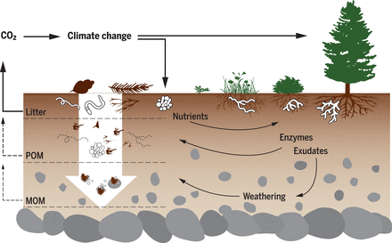

Fig. 3 Above- and belowground linkages in a changing climate.

Mountain plants transfer >50% of assimilated C to roots, to associated mycorrhizal fungi in exchange for soil nutrients, and to free-living bacteria and fungi feeding on rhizodeposits. Within hours, photosynthetic products are allocated belowground, nourishing soil organisms, and are respired back to the atmosphere as CO<sub>2</sub> (*14*, *31*). On an annual time scale, leaf and root residues enter the soils and are broken down and transformed by soil biota. Only a small fraction—microbial products—are stabilized by reactive minerals formed during weathering and persist in the soil for centuries to millennia (*31*). Consequently, SOM consists of a continuum of compounds from litter to particulate organic matter (POM) made up of decomposing plant and microbial residues and more stable mineral-associated organic matter (MOM) (*33*, *43*). Climate change affects above- and belowground linkages either directly through higher temperatures accelerating C and nutrient cycling, or indirectly as vegetation changes alter the quantity and quality of litter inputs into soils and modify the microclimate. Because SOM represents the key reservoir for water and nutrients and hosts soil microbial communities, changes in SOM will feed back to mountain vegetation shifts in a warming climate.

## Short-term and direct effects of climate warming

Higher temperatures accelerate the metabolic activity of organisms both above- and belowground, which strongly affects C and nutrient cycling. In mountain ecosystems, experimental warming stimulates plant productivity unless water is limiting (*9*, *28*) (table S1). Heating soils by 4°C at the alpine treeline and in montane forests increased soil CO<sub>2</sub> effluxes by 40 to 50%, resulting from both accelerated rhizosphere activity and enhanced soil C mineralization (*24*, *29*). These responses are likely transient as microbial communities acclimate to warmer conditions, without substantially changing their community structure, and soils become depleted in readily available C until a new quasi-equilibrium is reached (*29*–*31*). The magnitude and duration of warming responses vary among studies, but longer-term experiments observed accelerated soil C mineralization for more than a decade (*29*, *30*) (table S1). Higher C losses through soil C mineralization tend to be compensated by increased soil C inputs from plants, resulting in small net effects on the soil C balance compared with the pronounced warming effects on soil C fluxes (*25*, *32*). Despite considerable research efforts, there is no consensus on the magnitude of warming effects on soil C storage (*25*). Soils of cold climates such as those at high latitude or elevation seem particularly vulnerable to warming because they contain inherently high C stocks and high amounts of labile C, potentially promoting strong and sustained soil C losses (*24*, *29*, *33*). However, warming effects are contingent on water availability, and in semi-arid mountains, the soil C balance appears less dependent on projected temperature changes than on variation in the amount and timing of precipitation (*34*). Impacts of climatic warming is especially large in permafrost soils that only exist above the shrubline in the European Alps but reach down to the subalpine zone in continental mountain ranges at middle and northern latitudes. On the Tibetan plateau, for instance, permafrost collapse has resulted in a 32% decline in soil C stocks in surface soils (*35*), and an alpine tundra meadow with discontinuous permafrost in Colorado was found to represent a substantial net C source to the atmosphere by releasing C from ancient buried soil C (*36*).

Plant growth in mountain ecosystems is strongly limited by soil nutrients (*7*), particularly by nitrogen (N) (*8*), of which >90% is bound to organic matter. N availability for plants is therefore predominantly driven by microbial mineralization, at rates that are naturally constrained by low temperatures in mountain ecosystems to <2% of total soil N per year (*37*). More rapid processing of SOM caused by warming therefore enhances N cycling, approximately doubling the release of plant available N and thereby stimulating the growth of some plant species (*9*, *27*, *38*) (table S1). Increased N contents in foliage, either resulting from higher N availability or a higher abundance of nitrophilous plants, can promote litter decomposition, further stimulating the release of N and generating a positive feedback to soil N availability (*39*). Conversely, in some cases, enhanced plant productivity can bind N in living biomass, decreasing available N (*9*). Warming-induced changes in N availability are also reflected in soil microbial communities. Soil warming at treeline led to the proliferation of ectomycorrhizal fungi (ECM) adapted to high N availability (*40*), which may have further longer-lasting consequences in these ecosystems owing to the importance of mycorrhizal fungi for soil C cycling and plant nutrient supply (*41*).

## Longer-term above- and belowground linkages

Over longer time scales, the upward migration of mountain vegetation affects the entire soil system. Whereas increasing canopy height caused by shrub and treeline advances cools the soil during the growing period (*4*), it warms it during winter by promoting the accumulation of an insulating snow cover (*16*). Higher winter soil temperatures stimulate soil processes driven by microbial communities (*36*, *42*) and enhance N mineralization that in turn stimulates shrub and tree growth in high elevation and latitude systems (*37*). On decadal, centennial, or even longer time scales, vegetation primarily affects the soil system by its influence on SOM. SOM is of central importance for climate feedbacks, represents a key reservoir for water and nutrients, and serves as a substrate for microbial communities. However, the impact of vegetation has to be disentangled from other key factors affecting SOM—climate and geochemistry—that can be of similar importance (*31*, *43*). To better understand how these processes might play out in response to future climate change, we can gain insight from studies of vegetation-soil interactions across elevation gradients, under the assumption that these represent plant-soil systems in quasi-equilibrium with current climate (*27*).

The large reservoir of SOM encompasses a continuum of compounds that can be separated into old mineral-associated organic matter (MOM), which is stabilized through its interaction with mineral surfaces, and labile young particulate organic matter (POM), which primarily consists of decomposing plant residues (Fig. 3) (*31*). In temperate soils, POM contributes only 10% of total SOM stocks, but high-elevation soils typically have POM fractions as high as 30 to 60%, including organic layers on top of mineral soils (*26*, *33*, *44*, *45*). On poorly weathered bedrock, SOM can even be entirely composed of POM. High POM accumulation reflects slow litter decomposition caused by low temperatures, the recalcitrant nature of plant residues with high contents of polyphenols (*45*–*47*), and the low abundance of soil fauna, especially earthworms, which limits the incorporation of litter into mineral soils (*48*). POM represents a soil C pool that is highly vulnerable to loss when plant inputs are altered through plant community shifts (e.g., by expansion of broadleaf forests) or when temperature constraints on microbial and faunal decomposition are alleviated by climatic warming.

Along elevation gradients, soil C stocks are very small in early successional alpine ecosystems where low C inputs from plants and slow weathering retard SOM accumulation (Figs. 2 and 3) (*49*, *50*). Soil C stocks typically peak in high-elevation forests, at treeline or in the shrub zone above, reaching up to 20 to 30 kg C m<sup>−2</sup> in the Swiss Alps, Andes, and Himalaya, and then declining in low-elevation forests, which have 5 to 20 kg C m<sup>−2</sup> smaller soil C stocks (*26*, *44*) (table S1). This decrease partially offsets C gains with increasing biomass (averaging 12 kg C m<sup>−2</sup> in Swiss forests), and can be explained by faster litter decomposition, higher litter quality, and a decreasing input of below- compared with aboveground litter (e.g., *51*). Moreover, forest trees may release labile root exudates, fueling microbial metabolism that in turn induces C losses from older SOM in a process known as priming (*6*). Shifts in the fungal community from ericoid mycorrhiza and arbuscular mycorrhiza under shrubs and grasses to ECM in forests (Fig. 2) may cause further soil C losses through mining for nutrients. In their quest for SOM-bound nutrients, ECM secrete powerful oxidative enzymes to outcompete free-living saprotrophic fungi and bacteria, which further promotes SOM decomposition (e.g., *41*). At the subarctic treeline, soil C stocks were found to decrease by 70% along transects from ericaceous shrubs to deciduous shrubs and forests (*6*). The decline was associated with an increasing C turnover and was closely correlated with ECM productivity, consistent with nutrient mining (*6*).

Elevational patterns of vegetation and SOM are partly reflected in soil microbial communities. Microbial biomass and the contribution of fungi compared with bacteria typically increase from the nival zone to treeline, but decreases in forest at lower elevations (*26*, *50*, *52*) (table S1). However, at the species level, elevational patterns in soil microbial diversity are heterogeneous and only weakly related to plant diversity (*53*). Early successional alpine habitats are an exception. Here, a higher microbial dependence on plant organic inputs provides for a tighter positive relationship between plant and microbial taxonomic richness (*50*, *52*). Nonetheless, elevational turnover in microbial community composition can be pronounced and varies according to plant type (*54*), suggesting that there will be interdependencies among plant and soil microbial responses to climate warming (Fig. 4).

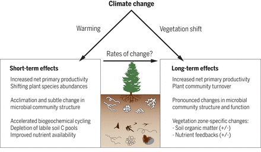

Fig. 4 Climate-warming impacts.

Climate warming affects mountain vegetation, soils, and their biota either directly or indirectly through elevational shifts of plant communities. See table S1 for pertinent examples from the literature.

## Implications of above- and belowground linkages in mountains

Collectively, the patterns of above- and belowground linkages in mountain ecosystems that have been observed from short-term experimental manipulations and across elevation gradients lead to several insights into how mountain vegetation and soil ecosystems might respond to changing climate, which we outline below.

1) Shifts in vegetation and the associated belowground system will feed back to climate warming through their impact on soil C, but this effect will differ between vegetation zones on mountains. Because of the peak in soil C storage and labile POM around treeline, soils are expected to gain C with advances of alpine grass and heathlands, but are highly vulnerable to C loss when forests shift upward. The latter might at least partly outweigh the increased C storage in tree biomass. Gradient studies provide no information about how fast these changes could occur, but soil C dynamics are known to follow a “slow in, fast out” principle, with a disparity between the rates of soil C gains and losses, as observed after land-use change (*55*). Overall, this pattern suggests that soil C will be lost with vegetation shifts in a warming climate, but the rates remain unknown. Studies along glacier forefields lend support for a slow SOM buildup (~2 kg C m<sup>−2</sup> in 100 years) as a result of slow vegetation succession and low weathering impeding SOM stabilization (*49*).

2) Plant migration and soil development operate at different time scales, such that chemical and physical processes belowground will constrain the rate of vegetation changes in mountains. The slow SOM accumulation and low nutrient availability in early-successional soils will restrict warming-induced shifts for a number of species, especially for those whose thermal tolerance would allow them to advance to high elevations but which require SOM and nutrient-rich soils (*21*). Paleobotanical studies show that time lags between suitable temperatures and upward migration of subalpine forests during the Holocene were as long as 3000 to 6000 years, possibly because of slow soil development after deglaciation (*20*). Nonetheless, feedbacks between plants and soil conditions will influence the rate of vegetation change, potentially facilitating plant establishment and growth. For example, SOM accumulation by cushion-forming plants facilitates the establishment of new plants in high-alpine ecosystems (*56*), whereas snow accumulating around taller plants prevents soils from freezing, which improves N availability and promotes plant growth (*16*, *37*).

3) Rhizosphere microbial communities are central to many soil processes and microbial community composition is likely to modulate the responses of mountain vegetation to climate change in both the short and long term. Asynchrony in the rates at which plants and their associated soil biota establish at higher elevations could affect plant population and community dynamics in the longer term (*57*). For instance, the absence of key mycorrhizal fungi (*58*) or the presence of soil pathogens (*59*) can limit the range expansions of trees, although the quantitative importance of such effects is poorly understood.

## Conclusions and future prospects

Above- and belowground linkages play a central role in the responses of ecosystem processes in mountains to climate warming, but in contrast to well-documented shifts in plant assemblages (*2*, *3*), changes in belowground systems remain largely unknown. Historically, high-elevation soils have not been analyzed quantitatively nor archived, and we still lack basic data on belowground plant productivity, the diversity and functional role of soil microbial communities, nutrient mineralization rates, and SOM stocks. To improve our limited understanding of plant-soil interactions in mountains, we need to address the following key questions:

1. How quickly will vegetation and belowground systems shift in response to changing climate, and how big will the corresponding feedbacks to climate be?

2. What is the role of parent material and its weathering on soil development and SOM accumulation in mountain ecosystems and how is it linked to vegetation change?

3. To what extent can warming-induced increases in nutrient availability keep pace with the increasing nutrient demands of upward-shifting plant communities?

4. What are the key drivers of soil biota across elevation gradients, how are they linked to vegetation, and what is the functional role of microbial communities in range shifts?

Elevation gradients document fundamental changes in the belowground system along mountain slopes, whereas soil-warming experiments frequently reveal that soil processes such as increased C and N mineralization are transient, counteracted by feedbacks, and difficult to detect in the large soil reservoir. Reconciling these sometimes conflicting observations is challenging; experiments rarely capture longer-term changes to ecosystems caused by turnover in species composition as range shifts occur, and gradient studies provide no information about the time scales of range shifts and ecosystems changes. However, the impacts of climate change on ecosystem functioning and climate feedbacks on time scales of decades to centuries will be governed by the nonequilibrium dynamics occurring during range shifts. There is therefore a need to bridge this gap and to better understand the rate and impacts of shifts in vegetation and belowground ecosystems using a suite of approaches.

First and most urgently, soils and their biota should be integrated into existing monitoring programs of vegetation change [e.g., GLORIA (*3*, *52*)] and national soil inventories, setting a baseline for assessing belowground changes over the coming decades. Second, temporal changes in soil ecosystems and their interactions with vegetation might be extrapolated by sampling current soils across chronosequences of vegetation changes that have been documented from historical photographs, maps, or satellite images, similar to studies conducted on glacial forefields (*37*, *49*). Third, comparative studies of plant-soil interactions across replicated elevation gradients within and between regions remain scarce (*27*), yet can exploit variation in the elevational covariance among climate, soil, land-use, and biological communities to gain insight into drivers of ecosystem structure and function, while filling data gaps in remote and understudied mountain regions. Finally, experiments might be conducted that approximate nonequilibrium conditions by manipulating climate and assembling the new combinations of plants, soils, and soil organisms that are expected after range shifts (*57*) and studying their impacts on ecosystem processes, ideally in combination with elevation gradient studies.

In many respects, the belowground still represents the “*Terra incognita*” of mountain ecosystems and, despite its importance for ecosystem functioning and global climate, the linkage between below- and aboveground ecosystems is one of the least understood research frontiers. Recent advances in molecular tools make it increasingly possible to open the “black box” of soil ecosystems, hopefully motivating renewed efforts to collect basic data on belowground process. Such information will be essential to accurately predict how current and future vegetation will interact with soil biota, soil chemistry, and physics, and how these interactions will feed back to climate change.

## Supplementary Materials

science.sciencemag.org/content/365/6458/1119/suppl/DC1

Table S1

References (*61*–*99*)

http://www.sciencemag.org/about/science-licenses-journal-article-reuse

This is an article distributed under the terms of the [Science Journals Default License](http://www.sciencemag.org/about/science-licenses-journal-article-reuse).

## References and Notes

1. ↵
   1. A. von Humboldt,
   2. A. Bonpland

   , Essai sur la géographie des plantes - accompagné d’un tableau physique des régions équinoxiales, fondé sur des mesures exécutées, depuis le dixième degré de latitute boréale jusqu’au dixième degré de latitute australe, pendant les années 1799, 1800. Schoell, Paris 1805, (1801). 10.3931/e-rara-24316

   Google Scholar
2. ↵
   1. P. Moret,
   2. P. Muriel,
   3. R. Jaramillo,
   4. O. Dangles

   , Humboldt’s *Tableau Physique* revisited. Proc. Natl. Acad. Sci. U.S.A. 116, 12889–12894 (2019). 10.1073/pnas.1904585116pmid:31138688

   Abstract/FREE Full TextGoogle Scholar
3. ↵
   1. M. J. Steinbauer,
   2. J.-A. Grytnes,
   3. G. Jurasinski,
   4. A. Kulonen,
   5. J. Lenoir,
   6. H. Pauli,
   7. C. Rixen,
   8. M. Winkler,
   9. M. Bardy-Durchhalter,
   10. E. Barni,
   11. A. D. Bjorkman,
   12. F. T. Breiner,
   13. S. Burg,
   14. P. Czortek,
   15. M. A. Dawes,
   16. A. Delimat,
   17. S. Dullinger,
   18. B. Erschbamer,
   19. V. A. Felde,
   20. O. Fernández-Arberas,
   21. K. F. Fossheim,
   22. D. Gómez-García,
   23. D. Georges,
   24. E. T. Grindrud,
   25. S. Haider,
   26. S. V. Haugum,
   27. H. Henriksen,
   28. M. J. Herreros,
   29. B. Jaroszewicz,
   30. F. Jaroszynska,
   31. R. Kanka,
   32. J. Kapfer,
   33. K. Klanderud,
   34. I. Kühn,
   35. A. Lamprecht,
   36. M. Matteodo,
   37. U. M. di Cella,
   38. S. Normand,
   39. A. Odland,
   40. S. L. Olsen,
   41. S. Palacio,
   42. M. Petey,
   43. V. Piscová,
   44. B. Sedlakova,
   45. K. Steinbauer,
   46. V. Stöckli,
   47. J.-C. Svenning,
   48. G. Teppa,
   49. J.-P. Theurillat,
   50. P. Vittoz,
   51. S. J. Woodin,
   52. N. E. Zimmermann,
   53. S. Wipf

   , Accelerated increase in plant species richness on mountain summits is linked to warming. Nature 556, 231–234 (2018). 10.1038/s41586-018-0005-6pmid:29618821

   [PubMed](https://science.sciencemag.org/lookup/external-ref?access_num=29618821&link_type=MED&atom=%2Fsci%2F365%2F6458%2F1119.atom)Google Scholar
4. ↵

   C. Körner, *Alpine Plant Life: Functional Plant Ecology of High Mountain Ecosystems* (Springer, 2003); https://link.springer.com/10.1007/978-3-642-18970-8.
5. ↵
   1. N. Pepin,
   2. R. S. Bradley,
   3. H. F. Diaz,
   4. M. Baraer,
   5. E. B. Caceres,
   6. N. Forsythe,
   7. H. Fowler,
   8. G. Greenwood,
   9. M. Z. Hashmi,
   10. X. D. Liu,
   11. J. R. Miller,
   12. L. Ning,
   13. A. Ohmura,
   14. E. Palazzi,
   15. I. Rangwala,
   16. W. Schöner,
   17. I. Severskiy,
   18. M. Shahgedanova,
   19. M. B. Wang,
   20. S. N. Williamson,
   21. D. Q. Yang

   , Elevation-dependent warming in mountain regions of the world. Nat. Clim. Chang. 5, 424–430 (2015). 10.1038/nclimate2563

   [CrossRef](https://science.sciencemag.org/lookup/external-ref?access_num=10.1038/nclimate2563&link_type=DOI)Google Scholar
6. ↵
   1. T. C. Parker,
   2. J.-A. Subke,
   3. P. A. Wookey

   , Rapid carbon turnover beneath shrub and tree vegetation is associated with low soil carbon stocks at a subarctic treeline. Glob. Change Biol. 21, 2070–2081 (2015). 10.1111/gcb.12793pmid:25367088

   [PubMed](https://science.sciencemag.org/lookup/external-ref?access_num=25367088&link_type=MED&atom=%2Fsci%2F365%2F6458%2F1119.atom)Google Scholar
7. ↵
   1. P. Möhl,
   2. M. A. Mörsdorf,
   3. M. A. Dawes,
   4. F. Hagedorn,
   5. P. Bebi,
   6. D. Viglietti,
   7. M. Freppaz,
   8. S. Wipf,
   9. C. Körner,
   10. F. M. Thomas,
   11. C. Rixen

   , Twelve years of low nutrient input stimulates growth of trees and dwarf shrubs in the treeline ecotone. J. Ecol. 107, 768–780 (2019). 10.1111/1365-2745.13073

   Google Scholar
8. ↵
   1. J. B. Fisher,
   2. Y. Malhi,
   3. I. C. Torres,
   4. D. B. Metcalfe,
   5. M. J. van de Weg,
   6. P. Meir,
   7. J. E. Silva-Espejo,
   8. W. H. Huasco

   , Nutrient limitation in rainforests and cloud forests along a 3,000-m elevation gradient in the Peruvian Andes. Oecologia 172, 889–902 (2013). 10.1007/s00442-012-2522-6pmid:23180422

   [CrossRef](https://science.sciencemag.org/lookup/external-ref?access_num=10.1007/s00442-012-2522-6&link_type=DOI)[PubMed](https://science.sciencemag.org/lookup/external-ref?access_num=23180422&link_type=MED&atom=%2Fsci%2F365%2F6458%2F1119.atom)Google Scholar
9. ↵
   1. M. A. Dawes,
   2. P. Schleppi,
   3. S. Hättenschwiler,
   4. C. Rixen,
   5. F. Hagedorn

   , Soil warming opens the nitrogen cycle at the alpine treeline. Glob. Change Biol. 23, 421–434 (2017). 10.1111/gcb.13365pmid:27207568

   [PubMed](https://science.sciencemag.org/lookup/external-ref?access_num=27207568&link_type=MED&atom=%2Fsci%2F365%2F6458%2F1119.atom)Google Scholar
10. ↵
    1. J. Paulsen,
    2. C. Körner

    , A climate-based model to predict potential treeline position around the globe. Alp. Bot. 124, 1–12 (2014). 10.1007/s00035-014-0124-0

    Google Scholar
11. ↵
    1. E. Liang,
    2. Y. Wang,
    3. S. Piao,
    4. X. Lu,
    5. J. J. Camarero,
    6. H. Zhu,
    7. L. Zhu,
    8. A. M. Ellison,
    9. P. Ciais,
    10. J. Peñuelas

    , Species interactions slow warming-induced upward shifts of treelines on the Tibetan Plateau. Proc. Natl. Acad. Sci. U.S.A. 113, 4380–4385 (2016). 10.1073/pnas.1520582113pmid:27044083

    Abstract/FREE Full TextGoogle Scholar
12. ↵
    1. M. A. Harsch,
    2. P. E. Hulme,
    3. M. S. McGlone,
    4. R. P. Duncan

    , Are treelines advancing? A global meta-analysis of treeline response to climate warming. Ecol. Lett. 12, 1040–1049 (2009). 10.1111/j.1461-0248.2009.01355.xpmid:19682007

    [CrossRef](https://science.sciencemag.org/lookup/external-ref?access_num=10.1111/j.1461-0248.2009.01355.x&link_type=DOI)[PubMed](https://science.sciencemag.org/lookup/external-ref?access_num=19682007&link_type=MED&atom=%2Fsci%2F365%2F6458%2F1119.atom)[Web of Science](https://science.sciencemag.org/lookup/external-ref?access_num=000269742600004&link_type=ISI)Google Scholar
13. ↵
    1. J. Dolezal,
    2. M. Dvorsky,
    3. M. Kopecky,
    4. P. Liancourt,
    5. I. Hiiesalu,
    6. M. Macek,
    7. J. Altman,
    8. Z. Chlumska,
    9. K. Rehakova,
    10. K. Capkova,
    11. J. Borovec,
    12. O. Mudrak,
    13. J. Wild,
    14. F. Schweingruber

    , Vegetation dynamics at the upper elevational limit of vascular plants in Himalaya. Sci. Rep. 6, 24881 (2016). 10.1038/srep24881pmid:27143226

    [PubMed](https://science.sciencemag.org/lookup/external-ref?access_num=27143226&link_type=MED&atom=%2Fsci%2F365%2F6458%2F1119.atom)Google Scholar
14. ↵
    1. A. Ferrari,
    2. F. Hagedorn,
    3. P. A. Niklaus

    , Experimental soil warming and cooling alters the partitioning of recent assimilates: Evidence from a (<sup>14)</sup>C-labelling study at the alpine treeline. Oecologia 181, 25–37 (2016). 10.1007/s00442-015-3427-ypmid:26314342

    [PubMed](https://science.sciencemag.org/lookup/external-ref?access_num=26314342&link_type=MED&atom=%2Fsci%2F365%2F6458%2F1119.atom)Google Scholar
15. ↵
    1. S. B. Rumpf,
    2. K. Hülber,
    3. G. Klonner,
    4. D. Moser,
    5. M. Schütz,
    6. J. Wessely,
    7. W. Willner,
    8. N. E. Zimmermann,
    9. S. Dullinger

    , Range dynamics of mountain plants decrease with elevation. Proc. Natl. Acad. Sci. U.S.A. 115, 1848–1853 (2018). 10.1073/pnas.1713936115pmid:29378939

    Abstract/FREE Full TextGoogle Scholar
16. ↵
    1. I. H. Myers-Smith,
    2. D. S. Hik

    , Climate warming as a driver of tundra shrubline advance. J. Ecol. 106, 547–560 (2018). 10.1111/1365-2745.12817

    Google Scholar
17. ↵
    1. J. M. Alexander,
    2. L. Chalmandrier,
    3. J. Lenoir,
    4. T. I. Burgess,
    5. F. Essl,
    6. S. Haider,
    7. C. Kueffer,
    8. K. McDougall,
    9. A. Milbau,
    10. M. A. Nuñez,
    11. A. Pauchard,
    12. W. Rabitsch,
    13. L. J. Rew,
    14. N. J. Sanders,
    15. L. Pellissier

    , Lags in the response of mountain plant communities to climate change. Glob. Change Biol. 24, 563–579 (2018). 10.1111/gcb.13976pmid:29112781

    [PubMed](https://science.sciencemag.org/lookup/external-ref?access_num=29112781&link_type=MED&atom=%2Fsci%2F365%2F6458%2F1119.atom)Google Scholar
18. ↵
    1. S. M. Crimmins,
    2. S. Z. Dobrowski,
    3. J. A. Greenberg,
    4. J. T. Abatzoglou,
    5. A. R. Mynsberge

    , Changes in climatic water balance drive downhill shifts in plant species’ optimum elevations. Science 331, 324–327 (2011). 10.1126/science.1199040pmid:21252344

    Abstract/FREE Full TextGoogle Scholar
19. ↵
    1. L. Lyu,
    2. Q.-B. Zhang,
    3. M. G. Pellatt,
    4. U. Büntgen,
    5. M.-H. Li,
    6. P. Cherubini

    , Drought limitation on tree growth at the Northern Hemisphere’s highest tree line. Dendrochronologia 53, 40–47 (2019). 10.1016/j.dendro.2018.11.006

    Google Scholar
20. ↵
    1. P. D. Henne,
    2. C. M. Elkin,
    3. B. Reineking,
    4. H. Bugmann,
    5. W. Tinner

    , Did soil development limit spruce (Picea abies) expansion in the Central Alps during the Holocene? Testing a palaeobotanical hypothesis with a dynamic landscape model. J. Biogeogr. 38, 933–949 (2011). 10.1111/j.1365-2699.2010.02460.x

    Google Scholar
21. ↵
    1. A. Kulonen,
    2. R. A. Imboden,
    3. C. Rixen,
    4. S. B. Maier,
    5. S. Wipf

    , Enough space in a warmer world? Microhabitat diversity and small-scale distribution of alpine plants on mountain summits. Divers. Distrib. 24, 252–261 (2018). 10.1111/ddi.12673

    Google Scholar
22. ↵
    1. J. HilleRisLambers,
    2. M. A. Harsch,
    3. A. K. Ettinger,
    4. K. R. Ford,
    5. E. J. Theobald

    , How will biotic interactions influence climate change-induced range shifts? Ann. N. Y. Acad. Sci. 1297, 112–125 (2013). 10.1111/nyas.12182pmid:23876073

    [PubMed](https://science.sciencemag.org/lookup/external-ref?access_num=23876073&link_type=MED&atom=%2Fsci%2F365%2F6458%2F1119.atom)[Web of Science](https://science.sciencemag.org/lookup/external-ref?access_num=000324840700009&link_type=ISI)Google Scholar
23. ↵
    1. W. H. van der Putten,
    2. M. A. Bradford,
    3. E. Pernilla Brinkman,
    4. T. F. J. van de Voorde,
    5. G. F. Veen

    , Where, when and how plant-soil feedback matters in a changing world. Funct. Ecol. 30, 1109–1121 (2016). 10.1111/1365-2435.12657

    Google Scholar
24. ↵
    1. K. Streit,
    2. F. Hagedorn,
    3. D. Hiltbrunner,
    4. M. Portmann,
    5. M. Saurer,
    6. N. Buchmann,
    7. B. Wild,
    8. A. Richter,
    9. S. Wipf,
    10. R. T. W. Siegwolf

    , Soil warming alters microbial substrate use in alpine soils. Glob. Change Biol. 20, 1327–1338 (2014). 10.1111/gcb.12396pmid:24106016

    [PubMed](https://science.sciencemag.org/lookup/external-ref?access_num=24106016&link_type=MED&atom=%2Fsci%2F365%2F6458%2F1119.atom)Google Scholar
25. ↵
    1. N. van Gestel,
    2. Z. Shi,
    3. K. J. van Groenigen,
    4. C. W. Osenberg,
    5. L. C. Andresen,
    6. J. S. Dukes,
    7. M. J. Hovenden,
    8. Y. Luo,
    9. A. Michelsen,
    10. E. Pendall,
    11. P. B. Reich,
    12. E. A. G. Schuur,
    13. B. A. Hungate

    , Predicting soil carbon loss with warming. Nature 554, E4–E5 (2018). 10.1038/nature25745pmid:29469098

    [PubMed](https://science.sciencemag.org/lookup/external-ref?access_num=29469098&link_type=MED&atom=%2Fsci%2F365%2F6458%2F1119.atom)Google Scholar
26. ↵
    1. A. T. Nottingham,
    2. J. Whitaker,
    3. B. L. Turner,
    4. N. Salinas,
    5. M. Zimmermann,
    6. Y. Malhi,
    7. P. Meir

    , Climate Warming and Soil Carbon in Tropical Forests: Insights from an Elevation Gradient in the Peruvian Andes. Bioscience 65, 906–921 (2015). 10.1093/biosci/biv109pmid:26955086

    [CrossRef](https://science.sciencemag.org/lookup/external-ref?access_num=10.1093/biosci/biv109&link_type=DOI)[PubMed](https://science.sciencemag.org/lookup/external-ref?access_num=26955086&link_type=MED&atom=%2Fsci%2F365%2F6458%2F1119.atom)Google Scholar
27. ↵
    1. J. R. Mayor,
    2. N. J. Sanders,
    3. A. T. Classen,
    4. R. D. Bardgett,
    5. J.-C. Clément,
    6. A. Fajardo,
    7. S. Lavorel,
    8. M. K. Sundqvist,
    9. M. Bahn,
    10. C. Chisholm,
    11. E. Cieraad,
    12. Z. Gedalof,
    13. K. Grigulis,
    14. G. Kudo,
    15. D. L. Oberski,
    16. D. A. Wardle

    , Elevation alters ecosystem properties across temperate treelines globally. Nature 542, 91–95 (2017). 10.1038/nature21027pmid:28117440

    [PubMed](https://science.sciencemag.org/lookup/external-ref?access_num=28117440&link_type=MED&atom=%2Fsci%2F365%2F6458%2F1119.atom)Google Scholar
28. ↵
    1. L. M. Kueppers,
    2. E. Conlisk,
    3. C. Castanha,
    4. A. B. Moyes,
    5. M. J. Germino,
    6. P. de Valpine,
    7. M. S. Torn,
    8. J. B. Mitton

    , Warming and provenance limit tree recruitment across and beyond the elevation range of subalpine forest. Glob. Change Biol. 23, 2383–2395 (2017). 10.1111/gcb.13561pmid:27976819

    [PubMed](https://science.sciencemag.org/lookup/external-ref?access_num=27976819&link_type=MED&atom=%2Fsci%2F365%2F6458%2F1119.atom)Google Scholar
29. ↵
    1. A. Schindlbacher,
    2. J. Schnecker,
    3. M. Takriti,
    4. W. Borken,
    5. W. Wanek

    , Microbial physiology and soil CO<sub>2</sub> efflux after 9 years of soil warming in a temperate forest - no indications for thermal adaptations. Glob. Change Biol. 21, 4265–4277 (2015). 10.1111/gcb.12996pmid:26046333

    [PubMed](https://science.sciencemag.org/lookup/external-ref?access_num=26046333&link_type=MED&atom=%2Fsci%2F365%2F6458%2F1119.atom)Google Scholar
30. ↵
    1. T. W. N. Walker,
    2. C. Kaiser,
    3. F. Strasser,
    4. C. W. Herbold,
    5. N. I. W. Leblans,
    6. D. Woebken,
    7. I. A. Janssens,
    8. B. D. Sigurdsson,
    9. A. Richter

    , Microbial temperature sensitivity and biomass change explain soil carbon loss with warming. Nat. Clim. Chang. 8, 885–889 (2018). 10.1038/s41558-018-0259-xpmid:30288176

    [PubMed](https://science.sciencemag.org/lookup/external-ref?access_num=30288176&link_type=MED&atom=%2Fsci%2F365%2F6458%2F1119.atom)Google Scholar
31. ↵
    1. M. A. Bradford,
    2. W. R. Wieder,
    3. G. B. Bonan,
    4. N. Fierer,
    5. P. A. Raymond,
    6. T. W. Crowther

    , Managing uncertainty in soil carbon feedbacks to climate change. Nat. Clim. Chang. 6, 751–758 (2016). 10.1038/nclimate3071

    Google Scholar
32. ↵
    1. J. Harte,
    2. S. R. Saleska,
    3. C. Levy

    , Convergent ecosystem responses to 23-year ambient and manipulated warming link advancing snowmelt and shrub encroachment to transient and long-term climate-soil carbon feedback. Glob. Change Biol. 21, 2349–2356 (2015). 10.1111/gcb.12831pmid:25504893

    [PubMed](https://science.sciencemag.org/lookup/external-ref?access_num=25504893&link_type=MED&atom=%2Fsci%2F365%2F6458%2F1119.atom)Google Scholar
33. ↵
    1. M. Zimmermann,
    2. J. Leifeld,
    3. F. Conen,
    4. M. I. Bird,
    5. P. Meir

    , Can composition and physical protection of soil organic matter explain soil respiration temperature sensitivity? Biogeochemistry 107, 423–436 (2012). 10.1007/s10533-010-9562-y

    [CrossRef](https://science.sciencemag.org/lookup/external-ref?access_num=10.1007/s10533-010-9562-y&link_type=DOI)Google Scholar
34. ↵
    1. A. B. Moyes,
    2. D. R. Bowling

    , Interannual variation in seasonal drivers of soil respiration in a semi-arid Rocky Mountain meadow. Biogeochemistry 113, 683–697 (2013). 10.1007/s10533-012-9797-x

    [CrossRef](https://science.sciencemag.org/lookup/external-ref?access_num=10.1007/s10533-012-9797-x&link_type=DOI)Google Scholar
35. ↵
    1. F. Liu,
    2. L. Chen,
    3. B. W. Abbott,
    4. Y. Xu,
    5. G. Yang,
    6. D. Kou,
    7. S. Qin,
    8. J. Strauss,
    9. Y. Wang,
    10. B. Zhang,
    11. Y. Yang

    , Reduced quantity and quality of SOM along a thaw sequence on the Tibetan Plateau. Environ. Res. Lett. 13, 104017 (2018). 10.1088/1748-9326/aae43b

    Google Scholar
36. ↵
    1. J. F. Knowles,
    2. P. D. Blanken,
    3. C. R. Lawrence,
    4. M. W. Williams

    , Evidence for non-steady-state carbon emissions from snow-scoured alpine tundra. Nat. Commun. 10, 1306 (2019). 10.1038/s41467-019-09149-2pmid:30898997

    [PubMed](https://science.sciencemag.org/lookup/external-ref?access_num=30898997&link_type=MED&atom=%2Fsci%2F365%2F6458%2F1119.atom)Google Scholar
37. ↵
    1. A. Kammer,
    2. F. Hagedorn,
    3. I. Shevchenko,
    4. J. Leifeld,
    5. G. Guggenberger,
    6. T. Goryacheva,
    7. A. Rigling,
    8. P. Moiseev

    , Treeline shifts in the Ural mountains affect soil organic matter dynamics. Glob. Change Biol. 15, 1570–1583 (2009). 10.1111/j.1365-2486.2009.01856.x

    Google Scholar
38. ↵
    1. J. T. Weedon,
    2. G. A. Kowalchuk,
    3. R. Aerts,
    4. J. van Hal,
    5. R. van Logtestijn,
    6. N. Taş,
    7. W. F. M. Röling,
    8. P. M. van Bodegom

    , Summer warming accelerates sub-arctic peatland nitrogen cycling without changing enzyme pools or microbial community structure. Glob. Change Biol. 18, 138–150 (2012). 10.1111/j.1365-2486.2011.02548.x

    Google Scholar
39. ↵
    1. S. E. Hobbie

    , Plant species effects on nutrient cycling: Revisiting litter feedbacks. Trends Ecol. Evol. 30, 357–363 (2015). 10.1016/j.tree.2015.03.015pmid:25900044

    [CrossRef](https://science.sciencemag.org/lookup/external-ref?access_num=10.1016/j.tree.2015.03.015&link_type=DOI)[PubMed](https://science.sciencemag.org/lookup/external-ref?access_num=25900044&link_type=MED&atom=%2Fsci%2F365%2F6458%2F1119.atom)Google Scholar
40. ↵
    1. E. F. Solly,
    2. B. D. Lindahl,
    3. M. A. Dawes,
    4. M. Peter,
    5. R. C. Souza,
    6. C. Rixen,
    7. F. Hagedorn

    , Experimental soil warming shifts the fungal community composition at the alpine treeline. New Phytol. 215, 766–778 (2017). 10.1111/nph.14603pmid:28543616

    [PubMed](https://science.sciencemag.org/lookup/external-ref?access_num=28543616&link_type=MED&atom=%2Fsci%2F365%2F6458%2F1119.atom)Google Scholar
41. ↵
    1. D. R. Zak,
    2. P. T. Pellitier,
    3. W. Argiroff,
    4. B. Castillo,
    5. T. Y. James,
    6. L. E. Nave,
    7. C. Averill,
    8. K. V. Beidler,
    9. J. Bhatnagar,
    10. J. Blesh,
    11. A. T. Classen,
    12. M. Craig,
    13. C. W. Fernandez,
    14. P. Gundersen,
    15. R. Johansen,
    16. R. T. Koide,
    17. E. A. Lilleskov,
    18. B. D. Lindahl,
    19. K. J. Nadelhoffer,
    20. R. P. Phillips,
    21. A. Tunlid

    , Exploring the role of ectomycorrhizal fungi in soil carbon dynamics. New Phytol. 223, 33–39 (2019). 10.1111/nph.15679pmid:30636276

    [PubMed](https://science.sciencemag.org/lookup/external-ref?access_num=30636276&link_type=MED&atom=%2Fsci%2F365%2F6458%2F1119.atom)Google Scholar
42. ↵
    1. R. K. Monson,
    2. D. L. Lipson,
    3. S. P. Burns,
    4. A. A. Turnipseed,
    5. A. C. Delany,
    6. M. W. Williams,
    7. S. K. Schmidt

    , Winter forest soil respiration controlled by climate and microbial community composition. Nature 439, 711–714 (2006). 10.1038/nature04555pmid:16467835

    [CrossRef](https://science.sciencemag.org/lookup/external-ref?access_num=10.1038/nature04555&link_type=DOI)[PubMed](https://science.sciencemag.org/lookup/external-ref?access_num=16467835&link_type=MED&atom=%2Fsci%2F365%2F6458%2F1119.atom)[Web of Science](https://science.sciencemag.org/lookup/external-ref?access_num=000235193100041&link_type=ISI)Google Scholar
43. ↵
    1. S. Doetterl,
    2. A. Stevens,
    3. J. Six,
    4. R. Merckx,
    5. K. Van Oost,
    6. M. Casanova Pinto,
    7. A. Casanova-Katny,
    8. C. Muñoz,
    9. M. Boudin,
    10. E. Zagal Venegas,
    11. P. Boeckx

    , Soil carbon storage controlled by interactions between geochemistry and climate. Nat. Geosci. 8, 780–783 (2015). 10.1038/ngeo2516

    Google Scholar
44. ↵
    1. S. Gosheva,
    2. L. Walthert,
    3. P. A. Niklaus,
    4. S. Zimmermann,
    5. U. Gimmi,
    6. F. Hagedorn

    , Reconstruction of historic forest cover changes indicates minor effects on carbon stocks in Swiss forest soils. Ecosystems (N. Y.) 20, 1512–1528 (2017). 10.1007/s10021-017-0129-9

    Google Scholar
45. ↵
    1. K. Budge,
    2. J. Leifeld,
    3. E. Hiltbrunner,
    4. J. Fuhrer

    , Alpine grassland soils contain large proportion of labile carbon but indicate long turnover times. Biogeosciences 8, 1911–1923 (2011). 10.5194/bg-8-1911-2011

    Google Scholar
46. ↵
    1. K. E. Clemmensen,
    2. A. Bahr,
    3. O. Ovaskainen,
    4. A. Dahlberg,
    5. A. Ekblad,
    6. H. Wallander,
    7. J. Stenlid,
    8. R. D. Finlay,
    9. D. A. Wardle,
    10. B. D. Lindahl

    , Roots and associated fungi drive long-term carbon sequestration in boreal forest. Science 339, 1615–1618 (2013). 10.1126/science.1231923pmid:23539604

    Abstract/FREE Full TextGoogle Scholar
47. ↵
    1. B. Adamczyk,
    2. O.-M. Sietiö,
    3. C. Biasi,
    4. J. Heinonsalo

    , Interaction between tannins and fungal necromass stabilizes fungal residues in boreal forest soils. New Phytol. 223, 16–21 (2019). 10.1111/nph.15729pmid:30721536

    [PubMed](https://science.sciencemag.org/lookup/external-ref?access_num=30721536&link_type=MED&atom=%2Fsci%2F365%2F6458%2F1119.atom)Google Scholar
48. ↵
    1. A. A. Wackett,
    2. K. Yoo,
    3. J. Olofsson,
    4. J. Klaminder

    , Human-mediated introduction of geoengineering earthworms in the Fennoscandian arctic. Biol. Invasions 20, 1377–1386 (2018). 10.1007/s10530-017-1642-7

    Google Scholar
49. ↵
    1. R. H. Smittenberg,
    2. M. Gierga,
    3. H. Göransson,
    4. I. Christl,
    5. D. Farinotti,
    6. S. M. Bernasconi

    , Climate-sensitive ecosystem carbon dynamics along the soil chronosequence of the Damma glacier forefield, Switzerland. Glob. Change Biol. 18, 1941–1955 (2012). 10.1111/j.1365-2486.2012.02654.x

    Google Scholar
50. ↵
    1. D. L. Porazinska,
    2. E. C. Farrer,
    3. M. J. Spasojevic,
    4. C. P. Bueno de Mesquita,
    5. S. A. Sartwell,
    6. J. G. Smith,
    7. C. T. White,
    8. A. J. King,
    9. K. N. Suding,
    10. S. K. Schmidt

    , Plant diversity and density predict belowground diversity and function in an early successional alpine ecosystem. Ecology 99, 1942–1952 (2018). 10.1002/ecy.2420pmid:30024640

    [PubMed](https://science.sciencemag.org/lookup/external-ref?access_num=30024640&link_type=MED&atom=%2Fsci%2F365%2F6458%2F1119.atom)Google Scholar
51. ↵
    1. G. Moser,
    2. C. Leuschner,
    3. D. Hertel,
    4. S. Graefe,
    5. N. Soethe,
    6. S. Iost

    , Elevation effects on the carbon budget of tropical mountain forests (S Ecuador): The role of the belowground compartment. Glob. Change Biol. 17, 2211–2226 (2011). 10.1111/j.1365-2486.2010.02367.x

    Google Scholar
52. ↵
    1. M. Adamczyk,
    2. F. Hagedorn,
    3. S. Wipf,
    4. J. Donhauser,
    5. P. Vittoz,
    6. C. Rixen,
    7. A. Frossard,
    8. J.-P. Theurillat,
    9. B. Frey

    , The Soil Microbiome of GLORIA Mountain Summits in the Swiss Alps. Front. Microbiol. 10, 1080 (2019). 10.3389/fmicb.2019.01080pmid:31156590

    [PubMed](https://science.sciencemag.org/lookup/external-ref?access_num=31156590&link_type=MED&atom=%2Fsci%2F365%2F6458%2F1119.atom)Google Scholar
53. ↵
    1. J. A. Bryant,
    2. C. Lamanna,
    3. H. Morlon,
    4. A. J. Kerkhoff,
    5. B. J. Enquist,
    6. J. L. Green

    , Colloquium paper: microbes on mountainsides: contrasting elevational patterns of bacterial and plant diversity. Proc. Natl. Acad. Sci. U.S.A. 105 (Suppl 1), 11505–11511 (2008). 10.1073/pnas.0801920105pmid:18695215

    Abstract/FREE Full TextGoogle Scholar
54. ↵
    1. S. N. Kivlin,
    2. J. S. Lynn,
    3. M. R. Kazenel,
    4. K. K. Beals,
    5. J. A. Rudgers

    , Biogeography of plant-associated fungal symbionts in mountain ecosystems: A meta-analysis. Divers. Distrib. 23, 1067–1077 (2017). 10.1111/ddi.12595

    Google Scholar
55. ↵
    1. C. Poeplau,
    2. A. Don,
    3. L. Vesterdal,
    4. J. Leifeld,
    5. B. Van Wesemael,
    6. J. Schumacher,
    7. A. Gensior

    , Temporal dynamics of soil organic carbon after land-use change in the temperate zone - carbon response functions as a model approach. Glob. Change Biol. 17, 2415–2427 (2011). 10.1111/j.1365-2486.2011.02408.x

    Google Scholar
56. ↵
    1. L. A. Cavieres,
    2. R. W. Brooker,
    3. B. J. Butterfield,
    4. B. J. Cook,
    5. Z. Kikvidze,
    6. C. J. Lortie,
    7. R. Michalet,
    8. F. I. Pugnaire,
    9. C. Schöb,
    10. S. Xiao,
    11. F. Anthelme,
    12. R. G. Björk,
    13. K. J. M. Dickinson,
    14. B. H. Cranston,
    15. R. Gavilán,
    16. A. Gutiérrez-Girón,
    17. R. Kanka,
    18. J.-P. Maalouf,
    19. A. F. Mark,
    20. J. Noroozi,
    21. R. Parajuli,
    22. G. K. Phoenix,
    23. A. M. Reid,
    24. W. M. Ridenour,
    25. C. Rixen,
    26. S. Wipf,
    27. L. Zhao,
    28. A. Escudero,
    29. B. F. Zaitchik,
    30. E. Lingua,
    31. E. T. Aschehoug,
    32. R. M. Callaway

    , Facilitative plant interactions and climate simultaneously drive alpine plant diversity. Ecol. Lett. 17, 193–202 (2014). 10.1111/ele.12217pmid:24238015

    [CrossRef](https://science.sciencemag.org/lookup/external-ref?access_num=10.1111/ele.12217&link_type=DOI)[PubMed](https://science.sciencemag.org/lookup/external-ref?access_num=24238015&link_type=MED&atom=%2Fsci%2F365%2F6458%2F1119.atom)Google Scholar
57. ↵
    1. A. Cardinaux,
    2. S. P. Hart,
    3. J. M. Alexander

    , Do soil biota influence the outcome of novel interactions between plant competitors? J. Ecol. 106, 1853–1863 (2018). 10.1111/1365-2745.13029pmid:30765896

    [PubMed](https://science.sciencemag.org/lookup/external-ref?access_num=30765896&link_type=MED&atom=%2Fsci%2F365%2F6458%2F1119.atom)Google Scholar
58. ↵
    1. M. A. Nuñez,
    2. T. R. Horton,
    3. D. Simberloff

    , Lack of belowground mutualisms hinders Pinaceae invasions. Ecology 90, 2352–2359 (2009). 10.1890/08-2139.1pmid:19769113

    [CrossRef](https://science.sciencemag.org/lookup/external-ref?access_num=10.1890/08-2139.1&link_type=DOI)[PubMed](https://science.sciencemag.org/lookup/external-ref?access_num=19769113&link_type=MED&atom=%2Fsci%2F365%2F6458%2F1119.atom)Google Scholar
59. ↵
    1. C. D. Brown,
    2. M. Vellend

    , Non-climatic constraints on upper elevational plant range expansion under climate change. Proc. Biol. Sci. 281, 20141779–20141779 (2014). 10.1098/rspb.2014.1779pmid:25253462

    [CrossRef](https://science.sciencemag.org/lookup/external-ref?access_num=10.1098/rspb.2014.1779&link_type=DOI)[PubMed](https://science.sciencemag.org/lookup/external-ref?access_num=25253462&link_type=MED&atom=%2Fsci%2F365%2F6458%2F1119.atom)Google Scholar
60. ↵
    1. C. P. Bueno de Mesquita,
    2. S. A. Sartwell,
    3. E. V. Ordemann,
    4. D. L. Porazinska,
    5. E. C. Farrer,
    6. A. J. King,
    7. M. J. Spasojevic,
    8. J. G. Smith,
    9. K. N. Suding,
    10. S. K. Schmidt

    , Patterns of root colonization by arbuscular mycorrhizal fungi and dark septate endophytes across a mostly-unvegetated, high-elevation landscape. Fungal Ecol. 36, 63–74 (2018). 10.1016/j.funeco.2018.07.009

    Google Scholar
61. ↵
    1. M. A. Dawes,
    2. C. D. Philipson,
    3. P. Fonti,
    4. P. Bebi,
    5. S. Hättenschwiler,
    6. F. Hagedorn,
    7. C. Rixen

    , Soil warming and CO<sub>2</sub> enrichment induce biomass shifts in alpine tree line vegetation. Glob. Change Biol. 21, 2005–2021 (2015). 10.1111/gcb.12819pmid:25471674

    [PubMed](https://science.sciencemag.org/lookup/external-ref?access_num=25471674&link_type=MED&atom=%2Fsci%2F365%2F6458%2F1119.atom)Google Scholar
62. 1. A. Anadon-Rosell,
    2. M. A. Dawes,
    3. P. Fonti,
    4. F. Hagedorn,
    5. C. Rixen,
    6. G. von Arx

    , Xylem anatomical and growth responses of the dwarf shrub Vaccinium myrtillus to experimental CO<sub>2</sub> enrichment and soil warming at treeline. Sci. Total Environ. 642, 1172–1183 (2018). 10.1016/j.scitotenv.2018.06.117pmid:30045499

    [PubMed](https://science.sciencemag.org/lookup/external-ref?access_num=30045499&link_type=MED&atom=%2Fsci%2F365%2F6458%2F1119.atom)Google Scholar
63. 1. S. C. Elmendorf,
    2. G. H. R. Henry,
    3. R. D. Hollister,
    4. A. M. Fosaa,
    5. W. A. Gould,
    6. L. Hermanutz,
    7. A. Hofgaard,
    8. I. S. Jónsdóttir,
    9. J. C. Jorgenson,
    10. E. Lévesque,
    11. B. Magnusson,
    12. U. Molau,
    13. I. H. Myers-Smith,
    14. S. F. Oberbauer,
    15. C. Rixen,
    16. C. E. Tweedie,
    17. M. D. Walker

    , Experiment, monitoring, and gradient methods used to infer climate change effects on plant communities yield consistent patterns. Proc. Natl. Acad. Sci. U.S.A. 112, 448–452 (2015). 10.1073/pnas.1410088112pmid:25548195

    Abstract/FREE Full TextGoogle Scholar
64. 1. E. Kaarlejärvi,
    2. A. Eskelinen,
    3. J. Olofsson

    , Herbivory prevents positive responses of lowland plants to warmer and more fertile conditions at high altitudes. Funct. Ecol. 27, 1244–1253 (2013). 10.1111/1365-2435.12113

    Google Scholar
65. 1. J. M. Melillo,
    2. S. Butler,
    3. J. Johnson,
    4. J. Mohan,
    5. P. Steudler,
    6. H. Lux,
    7. E. Burrows,
    8. F. Bowles,
    9. R. Smith,
    10. L. Scott,
    11. C. Vario,
    12. T. Hill,
    13. A. Burton,
    14. Y.-M. Zhou,
    15. J. Tang

    , Soil warming, carbon-nitrogen interactions, and forest carbon budgets. Proc. Natl. Acad. Sci. U.S.A. 108, 9508–9512 (2011). 10.1073/pnas.1018189108pmid:21606374

    Abstract/FREE Full TextGoogle Scholar
66. 1. H. Majdi,
    2. J. Ohrvik

    , Interactive effects of soil warming and fertilization on root production, mortality, and longevity in a Norway spruce stand in Northern Sweden. Glob. Change Biol. 10, 182–188 (2004). 10.1111/j.1365-2486.2004.00733.x

    Google Scholar
67. 1. E. F. Solly,
    2. I. Brunner,
    3. H.-S. Helmisaari,
    4. C. Herzog,
    5. J. Leppälammi-Kujansuu,
    6. I. Schöning,
    7. M. Schrumpf,
    8. F. H. Schweingruber,
    9. S. E. Trumbore,
    10. F. Hagedorn

    , Unravelling the age of fine roots of temperate and boreal forests. Nat. Commun. 9, 3006 (2018). 10.1038/s41467-018-05460-6pmid:30068916

    [PubMed](https://science.sciencemag.org/lookup/external-ref?access_num=30068916&link_type=MED&atom=%2Fsci%2F365%2F6458%2F1119.atom)Google Scholar
68. 1. E. F. Solly,
    2. I. Djukic,
    3. P. A. Moiseev,
    4. N. I. Andreyashkina,
    5. N. M. Devi,
    6. H. Göransson,
    7. V. S. Mazepa,
    8. S. G. Shiyatov,
    9. M. R. Trubina,
    10. F. H. Schweingruber,
    11. M. Wilmking,
    12. F. Hagedorn

    , Treeline advances and associated shifts in the ground vegetation alter fine root dynamics and mycelia production in the South and Polar Urals. Oecologia 183, 571–586 (2017). 10.1007/s00442-016-3785-0pmid:27904966

    [PubMed](https://science.sciencemag.org/lookup/external-ref?access_num=27904966&link_type=MED&atom=%2Fsci%2F365%2F6458%2F1119.atom)Google Scholar
69. 1. J. M. Melillo,
    2. S. D. Frey,
    3. K. M. DeAngelis,
    4. W. J. Werner,
    5. M. J. Bernard,
    6. F. P. Bowles,
    7. G. Pold,
    8. M. A. Knorr,
    9. A. S. Grandy

    , Long-term pattern and magnitude of soil carbon feedback to the climate system in a warming world. Science 358, 101–105 (2017). 10.1126/science.aan2874pmid:28983050

    Abstract/FREE Full TextGoogle Scholar
70. 1. H. Lim,
    2. R. Oren,
    3. T. Näsholm,
    4. M. Strömgren,
    5. T. Lundmark,
    6. H. Grip,
    7. S. Linder

    , Boreal forest biomass accumulation is not increased by two decades of soil warming. Nat. Clim. Chang. 9, 49–52 (2019). 10.1038/s41558-018-0373-9

    Google Scholar
71. 1. M. Väisänen,
    2. H. Ylänne,
    3. E. Kaarlejärvi,
    4. S. Sjögersten,
    5. J. Olofsson,
    6. N. Crout,
    7. S. Stark

    , Consequences of warming on tundra carbon balance determined by reindeer grazing history. Nat. Clim. Chang. 4, 384–388 (2014). 10.1038/nclimate2147

    Google Scholar
72. 1. S. B. Devi,
    2. S. S. S. S. Sherpa

    , Soil carbon and nitrogen stocks along the altitudinal gradient of the Darjeeling Himalayas, India. Environ. Monit. Assess. 191, 361 (2019). 10.1007/s10661-019-7470-8pmid:31079209

    [PubMed](https://science.sciencemag.org/lookup/external-ref?access_num=31079209&link_type=MED&atom=%2Fsci%2F365%2F6458%2F1119.atom)Google Scholar
73. 1. M. G. Kramer,
    2. O. A. Chadwick

    , Controls on carbon storage and weathering in volcanic soils across a high-elevation climate gradient on Mauna Kea, Hawaii. Ecology 97, 2384–2395 (2016). 10.1002/ecy.1467pmid:27859095

    [PubMed](https://science.sciencemag.org/lookup/external-ref?access_num=27859095&link_type=MED&atom=%2Fsci%2F365%2F6458%2F1119.atom)Google Scholar
74. 1. J. D. M. Speed,
    2. V. Martinsen,
    3. A. J. Hester,
    4. Ø. Holand,
    5. J. Mulder,
    6. A. Mysterud,
    7. G. Austrheim

    , Continuous and discontinuous variation in ecosystem carbon stocks with elevation across a treeline ecotone. Biogeosciences 12, 1615–1627 (2015). 10.5194/bg-12-1615-2015

    Google Scholar
75. 1. J. Leifeld,
    2. M. Zimmermann,
    3. J. Fuhrer,
    4. F. Conen

    , Storage and turnover of carbon in grassland soils along an elevation gradient in the Swiss Alps. Glob. Change Biol. 15, 668–679 (2009). 10.1111/j.1365-2486.2008.01782.x

    Google Scholar
76. 1. E. Kolb,
    2. M. Kohlpaintner

    , Tangel humus forms − genesis and co-evolution with vegetation. Appl. Soil Ecol. 123, 622–626 (2018). 10.1016/j.apsoil.2017.09.040

    Google Scholar
77. 1. M. A. Dawes,
    2. P. Schleppi,
    3. F. Hagedorn

    , The fate of nitrogen inputs in a warmer alpine treeline ecosystem: A <sup>15</sup>N labelling study. J. Ecol. 105, 1723–1737 (2017). 10.1111/1365-2745.12780

    Google Scholar
78. 1. Z. Wu,
    2. P. Dijkstra,
    3. G. W. Koch,
    4. B. A. Hungate

    , Biogeochemical and ecological feedbacks in grassland responses to warming. Nat. Clim. Chang. 2, 458–461 (2012). 10.1038/nclimate1486

    Google Scholar
79. 1. S. Zhang,
    2. D. Chen,
    3. D. Sun,
    4. X. Wang,
    5. J. L. Smith,
    6. G. Du

    , Impacts of altitude and position on the rates of soil nitrogen mineralization and nitrification in alpine meadows on the eastern Qinghai–Tibetan Plateau, China. Biol. Fertil. Soils 48, 393–400 (2012). 10.1007/s00374-011-0634-5

    Google Scholar
80. 1. L. Wang,
    2. D. L. Godbold

    , Soil N mineralization profiles of co-existing woody vegetation islands at the alpine tree line. Eur. J. For. Res. 136, 881–892 (2017). 10.1007/s10342-017-1076-x

    Google Scholar
81. 1. A. P. Baldos,
    2. M. D. Corre,
    3. E. Veldkamp

    , Response of N cycling to nutrient inputs in forest soils across a 1000-3000 m elevation gradient in the Ecuadorian Andes. Ecology 96, 749–761 (2015). 10.1890/14-0295.1pmid:26236871

    [CrossRef](https://science.sciencemag.org/lookup/external-ref?access_num=10.1890/14-0295.1&link_type=DOI)[PubMed](https://science.sciencemag.org/lookup/external-ref?access_num=26236871&link_type=MED&atom=%2Fsci%2F365%2F6458%2F1119.atom)Google Scholar
82. 1. A. Fajardo,
    2. F. I. Piper

    , An assessment of carbon and nutrient limitations in the formation of the southern Andes tree line. J. Ecol. 105, 517–527 (2017). 10.1111/1365-2745.12697

    Google Scholar
83. 1. A. Thébault,
    2. J.-C. Clément,
    3. S. Ibanez,
    4. J. Roy,
    5. R. A. Geremia,
    6. C. A. Pérez,
    7. A. Buttler,
    8. Y. Estienne,
    9. S. Lavorel

    , Nitrogen limitation and microbial diversity at the treeline. Oikos 123, 729–740 (2014). 10.1111/j.1600-0706.2013.00860.x

    [CrossRef](https://science.sciencemag.org/lookup/external-ref?access_num=10.1111/j.1600-0706.2013.00860.x&link_type=DOI)Google Scholar
84. 1. K. Gavazov,
    2. F. Hagedorn,
    3. A. Buttler,
    4. R. Siegwolf,
    5. L. Bragazza

    , Environmental drivers of carbon and nitrogen isotopic signatures in peatland vascular plants along an altitude gradient. Oecologia 180, 257–264 (2016). 10.1007/s00442-015-3458-4pmid:26433961

    [PubMed](https://science.sciencemag.org/lookup/external-ref?access_num=26433961&link_type=MED&atom=%2Fsci%2F365%2F6458%2F1119.atom)Google Scholar
85. 1. R. Amundson,
    2. A. T. Austin,
    3. E. A. G. Schuur,
    4. K. Yoo,
    5. V. Matzek,
    6. C. Kendall,
    7. A. Uebersax,
    8. D. Brenner,
    9. W. T. Baisden

    , Global patterns of the isotopic composition of soil and plant nitrogen. Global Biogeochem. Cycles 17, (2003). 10.1029/2002GB001903

    Google Scholar
86. 1. C. Körner,
    2. S. Leuzinger,
    3. S. Riedl,
    4. R. T. Siegwolf,
    5. L. Streule

    , Carbon and nitrogen stable isotope signals for an entire alpine flora, based on herbarium samples. Alp. Bot. 126, 153–166 (2016). 10.1007/s00035-016-0170-x

    Google Scholar
87. 1. Y. Yang,
    2. R. T. W. Siegwolf,
    3. C. Körner

    , Species specific and environment induced variation of δ(<sup>13)</sup>C and δ(<sup>15)</sup>N in alpine plants. Front. Plant Sci. 6, 423 (2015). 10.3389/fpls.2015.00423pmid:26097487

    [PubMed](https://science.sciencemag.org/lookup/external-ref?access_num=26097487&link_type=MED&atom=%2Fsci%2F365%2F6458%2F1119.atom)Google Scholar
88. 1. C. Heer,
    2. C. Körner

    , High elevation pioneer plants are sensitive to mineral nutrient addition. Basic Appl. Ecol. 3, 39–47 (2002). 10.1078/1439-1791-00075

    Google Scholar
89. 1. K. Klanderud

    , Species-specific responses of an alpine plant community under simulated environmental change. J. Veg. Sci. 19, 363–372 (2008). 10.3170/2008-8-18376

    Google Scholar
90. 1. B. Sveinbjornsson,
    2. O. Nordell,
    3. H. Kauhanen

    , Nutrient Relations of Mountain Birch Growth at and Below the Elevational Tree-Line in Swedish Lapland. Funct. Ecol. 6, 213 (1992). 10.2307/2389757

    Google Scholar
91. 1. S. Bassin,
    2. M. Volk,
    3. J. Fuhrer

    , Species Composition of Subalpine Grassland is Sensitive to Nitrogen Deposition, but Not to Ozone, After Seven Years of Treatment. Ecosystems 16, 1105–1117 (2013). 10.1007/s10021-013-9670-3

    Google Scholar
92. 1. K. E. Clemmensen,
    2. A. Michelsen,
    3. S. Jonasson,
    4. G. R. Shaver

    , Increased ectomycorrhizal fungal abundance after long-term fertilization and warming of two arctic tundra ecosystems. New Phytol. 171, 391–404 (2006). 10.1111/j.1469-8137.2006.01778.xpmid:16866945

    [CrossRef](https://science.sciencemag.org/lookup/external-ref?access_num=10.1111/j.1469-8137.2006.01778.x&link_type=DOI)[PubMed](https://science.sciencemag.org/lookup/external-ref?access_num=16866945&link_type=MED&atom=%2Fsci%2F365%2F6458%2F1119.atom)[Web of Science](https://science.sciencemag.org/lookup/external-ref?access_num=000238913500015&link_type=ISI)Google Scholar
93. 1. N. Fierer,
    2. C. M. McCain,
    3. P. Meir,
    4. M. Zimmermann,
    5. J. M. Rapp,
    6. M. R. Silman,
    7. R. Knight

    , Microbes do not follow the elevational diversity patterns of plants and animals. Ecology 92, 797–804 (2011). 10.1890/10-1170.1pmid:21661542

    [CrossRef](https://science.sciencemag.org/lookup/external-ref?access_num=10.1890/10-1170.1&link_type=DOI)[PubMed](https://science.sciencemag.org/lookup/external-ref?access_num=21661542&link_type=MED&atom=%2Fsci%2F365%2F6458%2F1119.atom)[Web of Science](https://science.sciencemag.org/lookup/external-ref?access_num=000290533700001&link_type=ISI)Google Scholar
94. 1. J. N. Hendershot,
    2. Q. D. Read,
    3. J. A. Henning,
    4. N. J. Sanders,
    5. A. T. Classen

    , Consistently inconsistent drivers of microbial diversity and abundance at macroecological scales. Ecology 98, 1757–1763 (2017). 10.1002/ecy.1829pmid:28380683

    [PubMed](https://science.sciencemag.org/lookup/external-ref?access_num=28380683&link_type=MED&atom=%2Fsci%2F365%2F6458%2F1119.atom)Google Scholar
95. 1. I. Djukic,
    2. F. Zehetner,
    3. A. Mentler,
    4. M. H. Gerzabek

    , Microbial community composition and activity in different Alpine vegetation zones. Soil Biol. Biochem. 42, 155–161 (2010). 10.1016/j.soilbio.2009.10.006

    [CrossRef](https://science.sciencemag.org/lookup/external-ref?access_num=10.1016/j.soilbio.2009.10.006&link_type=DOI)[Web of Science](https://science.sciencemag.org/lookup/external-ref?access_num=000273946300004&link_type=ISI)Google Scholar
96. 1. J. Donhauser,
    2. B. Frey

    , Alpine soil microbial ecology in a changing world. FEMS Microbiol. Ecol. 94, 1–31 (2018). 10.1093/femsec/fiy099pmid:30032189

    [CrossRef](https://science.sciencemag.org/lookup/external-ref?access_num=10.1093/femsec/fiy104&link_type=DOI)[PubMed](https://science.sciencemag.org/lookup/external-ref?access_num=30032189&link_type=MED&atom=%2Fsci%2F365%2F6458%2F1119.atom)Google Scholar
97. 1. R. D. Bardgett,
    2. A. Richter,
    3. R. Bol,
    4. M. H. Garnett,
    5. R. Bäumler,
    6. X. Xu,
    7. E. Lopez-Capel,
    8. D. A. C. Manning,
    9. P. J. Hobbs,
    10. I. R. Hartley,
    11. W. Wanek

    , Heterotrophic microbial communities use ancient carbon following glacial retreat. Biol. Lett. 3, 487–490 (2007). 10.1098/rsbl.2007.0242pmid:17609172

    [CrossRef](https://science.sciencemag.org/lookup/external-ref?access_num=10.1098/rsbl.2007.0242&link_type=DOI)[PubMed](https://science.sciencemag.org/lookup/external-ref?access_num=17609172&link_type=MED&atom=%2Fsci%2F365%2F6458%2F1119.atom)[Web of Science](https://science.sciencemag.org/lookup/external-ref?access_num=000249421800010&link_type=ISI)Google Scholar
98. 1. M. Bahram,
    2. F. Hildebrand,
    3. S. K. Forslund,
    4. J. L. Anderson,
    5. N. A. Soudzilovskaia,
    6. P. M. Bodegom,
    7. J. Bengtsson-Palme,
    8. S. Anslan,
    9. L. P. Coelho,
    10. H. Harend,
    11. J. Huerta-Cepas,
    12. M. H. Medema,
    13. M. R. Maltz,
    14. S. Mundra,
    15. P. A. Olsson,
    16. M. Pent,
    17. S. Põlme,
    18. S. Sunagawa,
    19. M. Ryberg,
    20. L. Tedersoo,
    21. P. Bork

    , Structure and function of the global topsoil microbiome. Nature 560, 233–237 (2018). 10.1038/s41586-018-0386-6pmid:30069051

    [CrossRef](https://science.sciencemag.org/lookup/external-ref?access_num=10.1038/s41586-018-0386-6&link_type=DOI)[PubMed](https://science.sciencemag.org/lookup/external-ref?access_num=30069051&link_type=MED&atom=%2Fsci%2F365%2F6458%2F1119.atom)Google Scholar
99. ↵
    1. C. Shen,
    2. Y. Shi,
    3. Y. Ni,
    4. Y. Deng,
    5. J. D. Van Nostrand,
    6. Z. He,
    7. J. Zhou,
    8. H. Chu

    , Dramatic increases of soil microbial functional gene diversity at the treeline ecotone of Changbai mountain. Front. Microbiol. 7, 1184 (2016). 10.3389/fmicb.2016.01184pmid:27524983

    [PubMed](https://science.sciencemag.org/lookup/external-ref?access_num=27524983&link_type=MED&atom=%2Fsci%2F365%2F6458%2F1119.atom)Google Scholar

**Acknowledgments:** We thank T. Walker for critical comments on the manuscript and the Stillberg team and P. Moiseev for their long-term support in treeline research. **Funding:** F.H. received funding from the Swiss National Science Foundation (grant no. 171171); K.G. was supported by funding from the Swiss National Science Foundation (grant no. PZ00P2_174047); and J.M.A. received funding from the European Union’s Horizon 2020 research and innovation program (grant no. 678841) and from the Swiss National Science Foundation (grant no. 31003A_176044). **Competing interests**: The authors declare no competing interests.